# Test

Javier Ng

2019-09-19

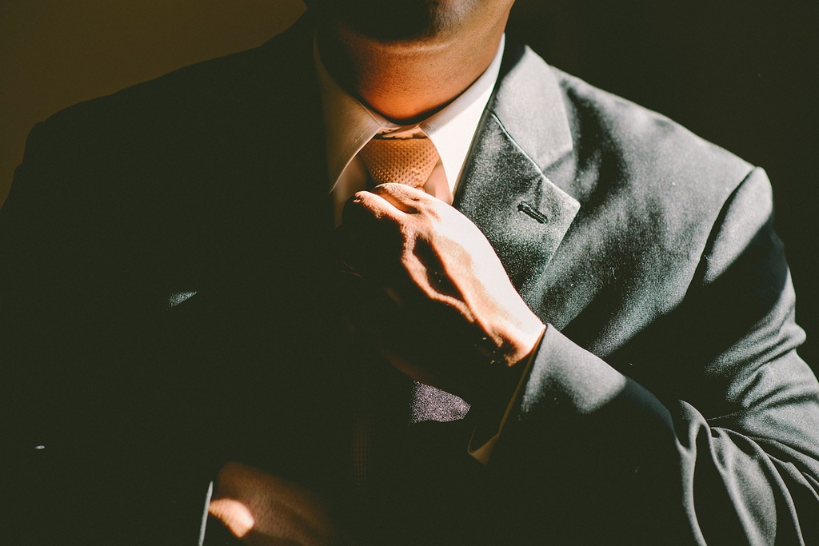

Since my graduation from university in 2017, I’ve talked to many graduates just like myself, who have just embarked on our career journey. Many of us are looking for a definitive path - a path of purpose, and the best way to build our careers from ground up. Living in an age where we are all so well-connected thanks to the prevalence of social media and the internet, it has become extremely easy for people to shift their career directions, following unconventional paths of entrepreneurship and online businesses.

For those of us who have a lower risk appetite and preferred a lifestyle of job stability and security, we would have chose the beaten path. As a young aspiring professional, I realized that some of my peers do not have the slightest idea on how to survive in the working world.

Therefore, in the spirit of sharing something more specific to your day-to-day work life, here are my career tips to fellow 20-something:

Blowing your top and losing your cool while at work is a strict no no, anywhere. Always maintain your composure no matter how aggravating the situation may be. Received an unfair email? Or were you just scolded by your boss? Take a step back and don’t respond without a clear head. When you act purely based on your emotions alone, you tend to burn bridges and can cause a conflict to spiral out of control.

3. Surround Yourself With Positivity

This is a useful tip both in your personal and professional life. Life is too short to constantly be in the trough of depression and negativity. Stay away from the toxic people in your life as they can be an energy drain. You won’t want to hinder your growth, right?

4. Dress for the Job You Want

Take note that this phrase does not refer to your dressing per say, but it refers to your attitude at work. It’s how you present yourself in the office, interact with your colleagues during meetings, and how seriously you take your work. Your day-to-day actions speak volumes about your attitude.

5. Exude Confidence

You are the writer of your life’s story. So be confident of your own abilities and don’t look down on yourself. Confidence in yourself will have a positive effect on yourself as it makes others have more faith in your abilities. Likewise, if you act timidly at work and shun away from opportunities, it will reflect badly on yourself.

6. Be Responsible of Your Choices

While there are definitely people out there who will want to help you, only you truly know what’s best for yourself. Never expect someone else to make major life decisions for yourself. With that said, be responsible of your own choices. Take all the time you need to discover your strengths, learn and create your own path. Don’t jump into any decision just because you may be pressured into them.

7. Tough Times Don’t Last

From the famous adage, “This too shall pass,” brings with it an important life advice. Remember that tough times don’t last and things will eventually turn out for the better. Even when you are feeling lost and overwhelmed by everything, I realized that one excellent way to stay afloat will be to be grateful. Be grateful for the things that are good even when you feel like you are balancing the whole world on your shoulders. Gratitude has been documented to generate success in individuals, so stay positive and this too, shall pass.

8. Love Yourself

Remember that a job will always be a job. No matter how fantastic it may be, it doesn’t give your life meaning, at least not by itself. Life is all about what you can eventually become, the growth you can experience, what you may learn and who you love and are loved by. Thus, don’t hurt your body by working too hard for your company. As harsh as it may sound, if you die for your job, you will simply be replaced. So take care of your health and remember to take a break at times!

9. Making Mistakes Can Be a Good Thing

While some mistakes can be a humbling experience, they can serve us well by letting us learn from it. Don’t let your fear of making mistake incapacitate you from trying new things. What’s important is that you learn from them and try not to make the same one again.

If you are looking for more general life tips, you can check out the [27 things I’ve learnt by 27](http://javierngkh.rbind.io/post/2018-12-08-things-you-learn-when-you-re-done-with-27/). Do you have any career advices that worked for you?